# Reproducable Researches Assignment 1

Natalijak

Februar 2016

```r
library(ggplot2)
```

Code for reading and data processing of the csv file “activity.csv”, packed in “repdata-data-activity.zip” Unordered process steps * Read data * Assign dimension type * Check data * Create additional column which stores the month only. This will be used for the charts / when plotting data it supports the readability , e.g which data day intervals belongs to which month * Exclude the NA values (these will be later included into new data set for the calculation of median/mean)

```r
data_activity <- read.csv("activity.csv", colClasses = c("integer", "Date", "factor"))
```

```r
head(data_activity)
```

```
##   steps       date interval
## 1    NA 2012-10-01        0
## 2    NA 2012-10-01        5
## 3    NA 2012-10-01       10
## 4    NA 2012-10-01       15
## 5    NA 2012-10-01       20
## 6    NA 2012-10-01       25
```

```r
names(data_activity)
```

```
## [1] "steps"    "date"     "interval"
```

```r
summary(data_activity)
```

```
##      steps             date               interval
##  Min.   :  0.00   Min.   :2012-10-01   0      :   61
##  1st Qu.:  0.00   1st Qu.:2012-10-16   10     :   61
##  Median :  0.00   Median :2012-10-31   100    :   61
##  Mean   : 37.38   Mean   :2012-10-31   1000   :   61
##  3rd Qu.: 12.00   3rd Qu.:2012-11-15   1005   :   61
##  Max.   :806.00   Max.   :2012-11-30   1010   :   61
##  NA's   :2304                          (Other):17202
```

```r
data_activity$month <- as.numeric(format(data_activity$date, "%m"))
```

```r
data_noNA <- na.omit((data_activity))
```

# Questions associated to the assignment

## What is the mean and total number of steps taken per day?

- For this part of the assignment, you can ignore the missing values in the dataset.
- Calculate the total number of steps taken per day

totalStepsPerDay <- sapply(stepsSplit, sum, na.rm = TRUE)

- Make a histogram of the total number of steps taken each day

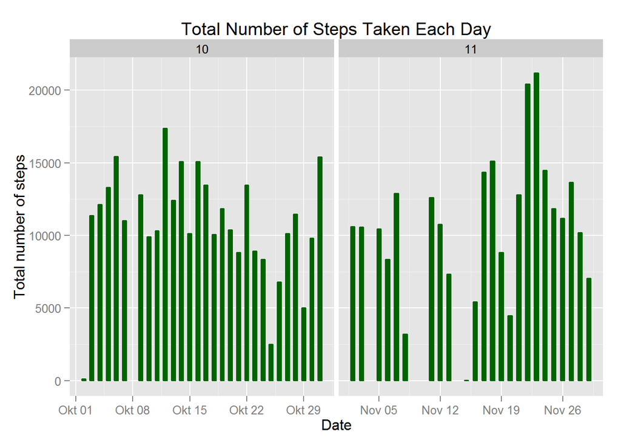

```r
ggplot(data_noNA, aes(date, steps)) + geom_bar(stat = "identity", colour = "darkgreen", fill = "darkgreen", width = 0.5) + facet_grid(. ~ month, scales = "free") + labs(title = "Total Number of Steps Taken Each Day", x = "Date", y = "Total number of steps")
```

- Mean and Median of steps taken per day:

```r
totSteps <- aggregate(data_noNA$steps, list(Date = data_noNA$date), FUN = "sum")$x
mean(totSteps) # Result Median total number of steps taken per day:
```

```
## [1] 10766.19
```

```r
#[1] 10766.19

median(totSteps)
```

```
## [1] 10765
```

```r
#[1] 10765
```

## What is the average daily activity pattern?

- Make a time series plot of the 5-minute interval (x-axis) and the average number of steps taken, averaged accross all days (y-axis)

```r
avgSteps <- aggregate(data_noNA$steps, list(interval = as.numeric(as.character(data_noNA$interval))), FUN = "mean")
#assigne the column name to the calculated mean, second column
```

```r
names(avgSteps) [2]<- "meanOfSteps"
```

## plot the data

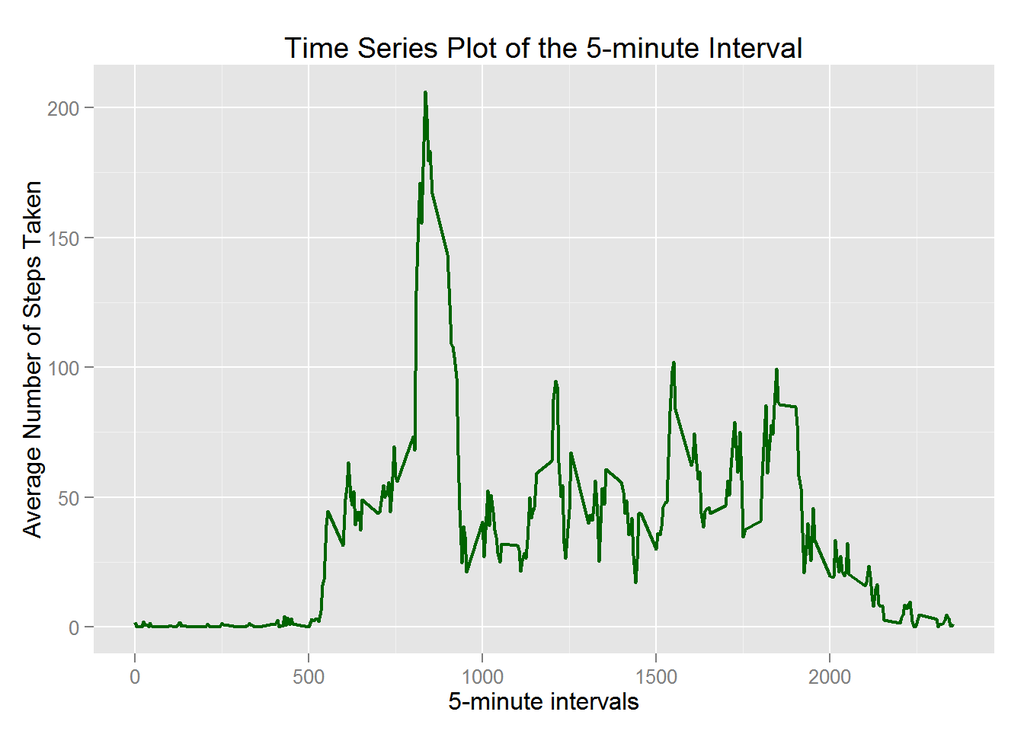

```r
ggplot(avgSteps, aes(interval, meanOfSteps)) + geom_line(color = "darkgreen", size = 0.8) + labs(title = "Time Series Plot of the 5-minute Interval", x = "5-minute intervals", y = "Average Number of Steps Taken")
```

- Which 5-minute interval, on average across all the days in the dataset, contains the maximum number of steps?

```r
avgSteps[avgSteps$meanOfSteps == max(avgSteps$meanOfSteps), ]
```

```
##     interval meanOfSteps
## 104      835    206.1698
```

```r
#interval   meanOfSteps
 # 835    206.1698
```

## Inputing missing values

- Calculate and report the total number of missing values in the dataset (total number of rows with NAs)

```r
total_NA <- sum(is.na(data_activity))
# print(total_NA)
# [1] 2304
```

- Devise a strategy for filling in all of the missing values in the dataset. The strategy does not need to be sophisticated. For example, you could use the mean/median for that day, or the mean for that 5-minute interval, etc.

```r
sum(is.na(data_activity))
```

```
## [1] 2304
```

```r
# [1] 2304 to be manipulated
```

Approach: using the mean for 5-minute interval, replace each NA value in the column = steps.

- Create a new dataset that is equal to the original dataset but with the missing data filled in.

```r
        data_manipulated <- data_activity
        for (i in 1:nrow(data_manipulated))
        {
                if (is.na(data_manipulated$steps[i]))
                {
                        data_manipulated$steps[i] <- avgSteps[which(data_manipulated$interval[i] == avgSteps$interval), ]$meanOfSteps
                }
        }


sum(is.na(data_manipulated))
```

```
## [1] 0
```

```r
        # [1] 0
head(data_manipulated)
```

```
##       steps       date interval month
## 1 1.7169811 2012-10-01        0    10
## 2 0.3396226 2012-10-01        5    10
## 3 0.1320755 2012-10-01       10    10
## 4 0.1509434 2012-10-01       15    10
## 5 0.0754717 2012-10-01       20    10
## 6 2.0943396 2012-10-01       25    10
```

- Make a histogram of the total number of steps taken each day and Calculate and report the mean and median total number of steps taken per day.

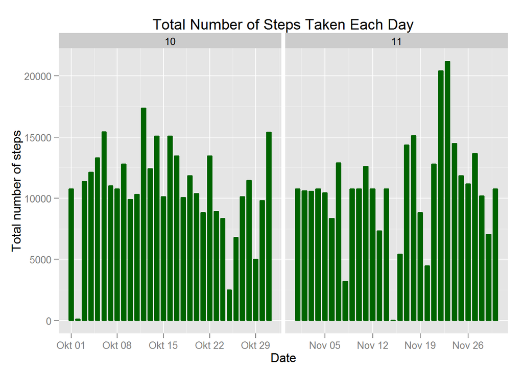

```r
ggplot(data_manipulated, aes(date, steps)) + geom_bar(stat = "identity",
                                                     colour = "darkgreen",
                                                     fill = "darkgreen",
                                                     width = 0.7) + facet_grid(. ~ month, scales = "free") + labs(title = "Total Number of Steps Taken Each Day", x = "Date", y = "Total number of steps")
```

- Do these values differ from the estimates fromt he first part of the assignment?

```r
newTotSteps <- aggregate(data_manipulated$steps, list(Date = data_manipulated$date), FUN = "sum")$x
new_mean <- mean(newTotSteps)
## [1] 10766.19
new_median <- median(newTotSteps)
## [1] 10766.19

old_mean <- mean(totSteps)
# [1] 10766.19
old_median <- median(totSteps)
print(old_median)
```

```
## [1] 10765
```

```r
#[1] 10765
# Comparisson old vs new  (after manipulating missing data):
new_mean - old_mean
```

```
## [1] 0
```

```r
## [1] 0
new_median - old_median
```

```
## [1] 1.188679
```

```r
## [1] 1.188679
```